# hw_2

Aiyman Akbar

2025-04-8

1. Pre-HW files:

```r
#load up files for use in this document

peru <- read_graph("peru.graphml", format = "graphml")

seattle <- read_graph("seattle.graphml", format = "graphml")

fifa <- read_graph("fifa_countries.graphml", format = "graphml")
```

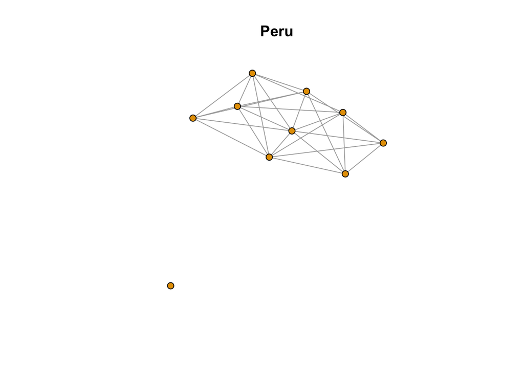

```r
#plot the files for visualization of the data I am working with

#plot Peru
plot(peru,
     vertex.label = NA, vertex.size = 6,
     main = "Peru")
```

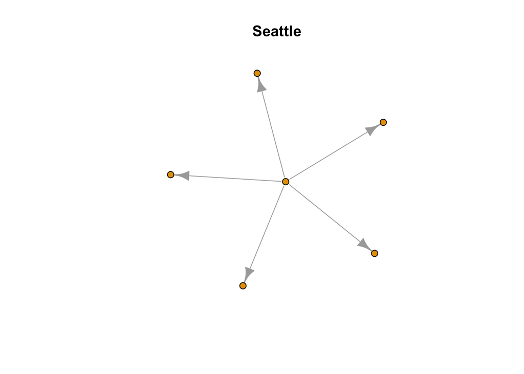

```r
#plot Seattle
plot(seattle,
     vertex.label = NA, vertex.size = 6,
     main = "Seattle")
```

[figure not shown]

```r
#plot FIFA
plot(fifa,
     vertex.label = V(fifa)$name, vertex.size = 5, edge.width = E(fifa)$weight,
     main = "FIFA Countries")
```

2. Use the Peruvian graph, and prepare a code in R to answer:

Use the Louvain and Leiden algorithm , and present a plot of both results. Which one should be chosen?

Louvian Algorithm:

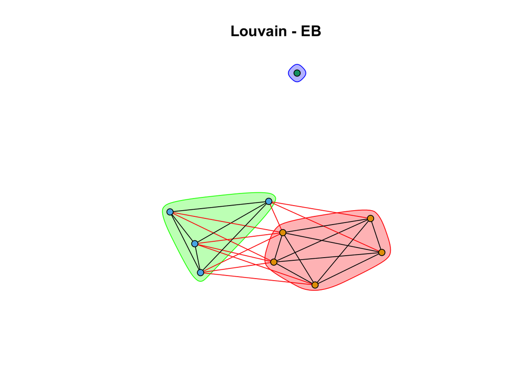

```r
#Louvain algorithm plot
louvain_peru <- cluster_louvain(peru)
plot(louvain_peru, peru, vertex.label = NA, vertex.size = 6,
     main = "Louvain - EB")
```

```r
#Louvain algorithm modularity
louvain_mod <- modularity(louvain_peru)
cat("Louvain Modularity:", louvain_mod, "\n")
```

```
## Louvain Modularity: 0.08161866
```

“Leiden” Algorithm:

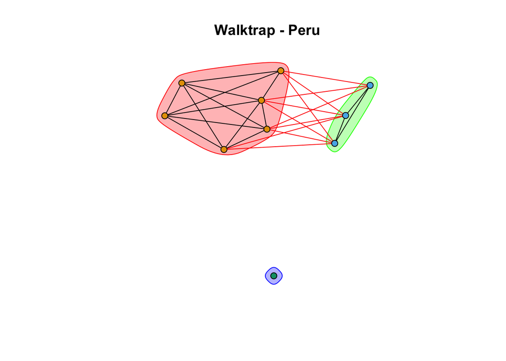

```r
#Because Leiden isnt supported in R through igraph I used Walktrap instead
walktrap_peru <- cluster_walktrap(peru)
plot(walktrap_peru, peru, vertex.label = NA, vertex.size = 6,
     main = "Walktrap - Peru")
```

```r
# Walktrap algorithm modularity
walktrap_mod <- modularity(walktrap_peru)
cat("Walktrap Modularity:", walktrap_mod, "\n")
```

```
## Walktrap Modularity: 0.02400549
```

After using both the Louvain and “Leiden” algorithms and presenting a plot for each, the Louvian algorithm should be chosen. It produced three different communities, including one clearly separated family and two other heavily packed clusters, making the structure of elite relationships easier to understand.

The “Leiden” algorithm, I used the Walktrap algorithm here instead as the actual Leiden algorithm doesn’t really work so well with R, also identified three communities, but its grouping was less clear and did not improve the modularity score or the interpretability, in my opinion. Also in the tutorial it mentioned that the Lauvian algorithm is more computationally efficient than these others.

3. Use the Seattle graph, and prepare a code in R to answer:

Use the Louvain and Leiden algorithm. Did any of them work? If it did not work, choose two other algorithms, and plot the result. Which one should be chosen from the two algorithms you chose?

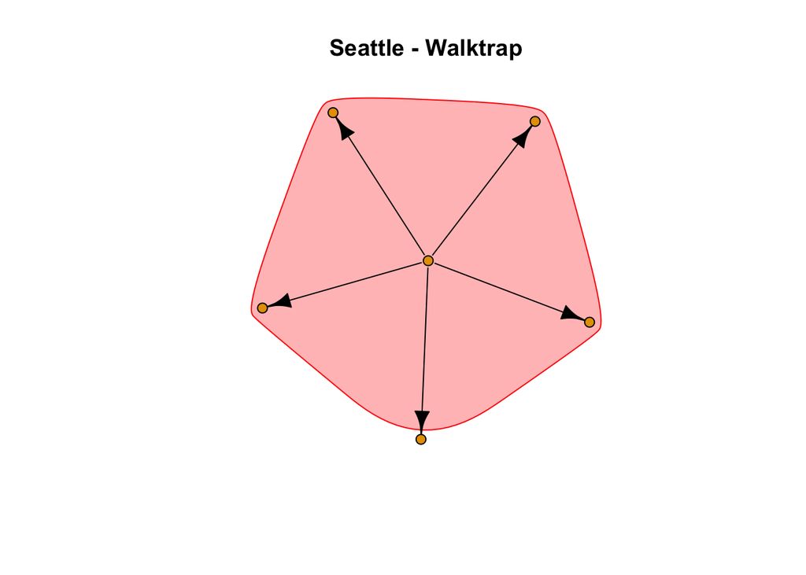

```r
# Walktrap algorithm:
walktrap_seattle <- cluster_walktrap(seattle)
plot(walktrap_seattle, seattle, vertex.label = NA, vertex.size = 6,
     main = "Seattle - Walktrap")
```

```r
modularity(walktrap_seattle)
```

```
## [1] 0
```

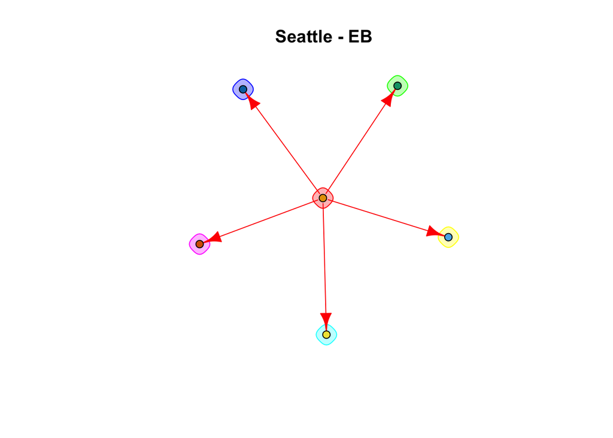

```r
# Girvan-Newman algorithm
betw_seattle <- cluster_edge_betweenness(seattle)
plot(betw_seattle, seattle, vertex.label = NA, vertex.size = 6,
     main = "Seattle - EB")
```

```r
modularity(betw_seattle)
```

```
## [1] 0
```

After attempting to use both the Louvain and “Leiden” algorithms on the Seattle graph, I found that Louvain did not work as it only works on undirected graphs, which Seattle is not. After figuring this out, I moved forward using two alternative algorithms, Walktrap and Girvan-Newman.

In my opinion, Girvan-Newman should be chosen. Not only did it produce more interpretable results, but it also better reflected the uneven nature of influence on Twitter, where relationships are not always mutual, like when one person follows another but doesnt get followed back. Even through the Louvain algorithm is more computationally efficient, but Girvan-Newman was more effective in this specific case due to the graph’s directional structure.

4. Use the Fifa graph, projecting only the countries (netwrom of countries), and report:

Use the Girvan-Newman and Leiden algorithm, and present a plot of both results. Which one should be chosen?

[figure not shown]

```r
# Girvan-Newman algorithm
gn_fifa <- cluster_edge_betweenness(fifa, weights = E(fifa)$weight)
plot(gn_fifa, fifa, vertex.label = V(fifa)$name, vertex.size = 6,
     main = "FIFA Countries - Girvan-Newman")
```

```r
modularity(gn_fifa)
```

```
## [1] NaN
```

[figure not shown]

```r
# Walktrap algorithm
walktrap_fifa <- cluster_walktrap(fifa, weights = E(fifa)$weight)
plot(walktrap_fifa, fifa, vertex.label = V(fifa)$name, vertex.size = 6,
     main = "FIFA Countries - Walktrap")
```

```r
modularity(walktrap_fifa)
```

```
## [1] NaN
```

The FIFA graph used shows how countries are connected based on having players in the same clubs. After projecting the bipartite network into just countries, each edge shows how many clubs two countries share players through. To find communities, I ran two algorithms. First was Girvan-Newman, which finds groups by removing the most important edges then I ran Walktrap like in the previous parts, which in this case grouped countries based on short random walks.